# Regresi dengan Peubah Lag

Farik Firsteadi Haristiyanto

2023-09-18

## Impor Data

```r
Data <- rio::import("https://raw.githubusercontent.com/Fhar1st/mpdw/main/Pertemuan%203/DATA%20-%20Minggu%203.csv")
colnames(Data) <- c("t", "Yt", "Y(t-1)", "Xt")
str(Data)
```

```
## 'data.frame':    318 obs. of  4 variables:
##  $ t     : int  1 2 3 4 5 6 7 8 9 10 ...
##  $ Yt    : num  75.7 74.8 73.3 75.8 79.5 79.3 81.1 79.9 80.2 82.4 ...
##  $ Y(t-1): num  NA 75.7 74.8 73.3 75.8 79.5 79.3 81.1 79.9 80.2 ...
##  $ Xt    : num  63.8 64.8 64.9 65.2 64.7 65.2 65.3 65.4 65.6 65.8 ...
```

```r
Data
```

```
##       t    Yt Y(t-1)    Xt
## 1     1  75.7     NA  63.8
## 2     2  74.8   75.7  64.8
## 3     3  73.3   74.8  64.9
## 4     4  75.8   73.3  65.2
## 5     5  79.5   75.8  64.7
## 6     6  79.3   79.5  65.2
## 7     7  81.1   79.3  65.3
## 8     8  79.9   81.1  65.4
## 9     9  80.2   79.9  65.6
## 10   10  82.4   80.2  65.8
## 11   11  83.0   82.4  66.1
## 12   12  84.3   83.0  66.4
## 13   13  79.1   84.3  66.2
## 14   14  84.8   79.1  66.7
```

[output cut: 304 more lines]

## Pembagian Data

```r
#SPLIT DATA
Train<-Data[1:238,]
Test<-Data[239:318,]
```

```r
#data time series
Train.ts<-ts(Train)
Test.ts<-ts(Test)
Data.ts<-ts(Data)
```

## Model Koyck

### Pemodelan

```r
#MODEL KOYCK
Model.koyck <- koyckDlm(x = Train$Xt, y = Train$Yt)
summary(Model.koyck)
```

```
##
## Call:
## "Y ~ (Intercept) + Y.1 + X.t"
##
## Residuals:
##      Min       1Q   Median       3Q      Max
## -18.2542  -2.2385  -0.2983   1.9398  25.1086
##
## Coefficients:
##             Estimate Std. Error t value Pr(>|t|)
## (Intercept)  9.02691    4.24820   2.125   0.0346 *
## Y.1          0.94438    0.02055  45.961   <2e-16 ***
## X.t         -0.04857    0.04121  -1.179   0.2398
## ---
## Signif. codes:  0 '***' 0.001 '**' 0.01 '*' 0.05 '.' 0.1 ' ' 1
##
## Residual standard error: 4.781 on 234 degrees of freedom
## Multiple R-Squared: 0.9085,  Adjusted R-squared: 0.9077
## Wald test:  1162 on 2 and 234 DF,  p-value: < 2.2e-16
##
## Diagnostic tests:
## NULL
##
##                             alpha        beta       phi
## Geometric coefficients:  162.3064 -0.04857131 0.9443835
```

```r
AIC(Model.koyck)
```

```
## [1] 1419.228
```

```r
BIC(Model.koyck)
```

```
## [1] 1433.1
```

### Peramalan dan Akurasi

Berikut adalah hasil peramalan y untuk 80 periode kedepan menggunakan model koyck

```r
Fore.koyck <- forecast(model = Model.koyck, x=Test$Xt, h=80)
Fore.koyck
```

```
## $forecasts
##  [1] 92.69792 91.93560 91.19624 90.49315 89.82430 89.18294 88.56268 87.97205
##  [9] 87.40942 86.86351 86.32367 85.81386 85.31783 84.86882 84.44478 84.04432
## [17] 83.64185 83.27148 82.90228 82.54389 82.19573 81.85721 81.53267 81.23103
## [25] 80.92674 80.64423 80.36286 80.07771 79.80842 79.57353 79.33714 79.09932
## [33] 78.85531 78.62486 78.38780 78.17364 77.98110 77.79442 77.60355 77.44758
## [41] 77.64513 78.77399 79.72835 80.29934 80.54230 80.67945 80.76041 80.81258
## [49] 80.93956 80.98176 81.15276 81.28511 81.31295 81.19839 81.03191 80.82613
## [57] 80.63664 80.41883 80.18400 79.95737 79.69477 79.44192 79.19342 78.96360
## [65] 78.74170 78.53214 78.29538 78.11065 77.91676 77.73365 77.59473 77.42954
## [73] 77.26867 77.14104 76.99622 76.85945 76.74001 76.61749 76.50665 76.37282
##
## $call
## forecast.koyckDlm(model = Model.koyck, x = Test$Xt, h = 80)
##
## attr(,"class")
## [1] "forecast.koyckDlm" "dLagM"
```

```r
Mape.koyck <- MAPE(Fore.koyck$forecasts, Test$Yt)
#akurasi data training
GoF(Model.koyck)
```

```
##               n      MAE          MPE       MAPE      sMAPE      MASE      MSE
## Model.koyck 237 3.152685 -0.002456101 0.03390863 0.03399139 0.9843018 22.57109
##                 MRAE     GMRAE
## Model.koyck 1.232581 0.9409145
```

## Regression with Distributed Lag

### Pemodelan (Lag=2)

```r
Model.dlm <- dlm(x = Train$Xt,y = Train$Yt , q = 2)
summary(Model.dlm)
```

```
##
## Call:
## lm(formula = model.formula, data = design)
##
## Residuals:
##     Min      1Q  Median      3Q     Max
## -27.852 -11.038  -3.884  11.290  39.491
##
## Coefficients:
##             Estimate Std. Error t value Pr(>|t|)
## (Intercept) 138.8639    10.2435  13.556   <2e-16 ***
## x.t           1.1430     2.4050   0.475    0.635
## x.1          -0.5649     2.8571  -0.198    0.843
## x.2          -1.1801     2.3811  -0.496    0.621
## ---
## Signif. codes:  0 '***' 0.001 '**' 0.01 '*' 0.05 '.' 0.1 ' ' 1
##
## Residual standard error: 15.09 on 232 degrees of freedom
## Multiple R-squared:  0.0926, Adjusted R-squared:  0.08087
## F-statistic: 7.892 on 3 and 232 DF,  p-value: 4.91e-05
##
## AIC and BIC values for the model:
##        AIC      BIC
## 1 1956.726 1974.045
```

```r
AIC(Model.dlm)
```

```
## [1] 1956.726
```

```r
BIC(Model.dlm)
```

```
## [1] 1974.045
```

Dari hasil diatas, didapat bahwa hanya $P-value$ dari intercept $<0.05$. Hal ini menunjukkan bahwa hanya intercept yang memilki pengaruh signifikan terhadap $y$. Adapun model keseluruhan yang terbentuk adalah sebagai berikut

$$\hat{Y_t}=138.8639+1.1430X_t-0.5649X_{t-1}-1.1801X_{t-2}$$

### Peramalan dan Akurasi

Berikut merupakan hasil peramalan $y$ untuk 80 periode kedepan

```r
Fore.dlm <- forecast(model = Model.dlm, x=Test$Xt, h=80)
Fore.dlm
```

```
## $forecasts
##  [1]  82.08370  81.84901  82.01371  81.78406  81.36983  81.42394  81.53587
##  [8]  81.24469  80.94847  81.11688  81.40093  80.76446  80.51731  79.89064
## [15]  79.76254  80.23459  80.80612  80.29508  80.27520  80.51389  80.15748
## [22]  80.03709  79.80240  79.39558  79.79127  79.56904  79.49638  79.90216
## [29]  79.32217  78.39290  78.96176  79.60727  79.54099  78.96101  78.94617
## [36]  78.49162  77.90393  78.36724  78.88969  78.03069  69.84346  52.26893
## [43]  74.23517 103.60321 104.02044  94.72169  87.59272  85.35713  82.06570
## [50]  84.20829  82.10649  82.42924  87.56276  89.03980  86.41310  83.45593
## [57]  81.36061  81.15141  81.50336  80.33464  80.71313  80.14456  79.13655
## [64]  78.79126  78.72603  78.78755  79.58398  78.21765  78.18265  78.90081
## [71]  77.62863  78.82416  79.36916  77.91506  78.65100  78.95863  78.13996
## [78]  78.48154  78.49029  78.99658
##
## $call
## forecast.dlm(model = Model.dlm, x = Test$Xt, h = 80)
##
## attr(,"class")
## [1] "forecast.dlm" "dLagM"
```

```r
Mape.dlm <- MAPE(Fore.dlm$forecasts, Test$Yt)
#akurasi data training
GoF(Model.dlm)
```

```
##             n      MAE         MPE      MAPE     sMAPE     MASE      MSE
## Model.dlm 236 12.44777 -0.02571939 0.1373096 0.1355141 3.877553 223.8463
##               MRAE    GMRAE
## Model.dlm 11.88632 4.512206
```

### *Lag* Optimum

```r
#penentuan lag optimum
finiteDLMauto(formula = Yt ~ Xt,
              data = data.frame(Train), q.min = 1, q.max = 6,
              model.type = "dlm", error.type = "AIC", trace = FALSE)
```

```
##   q - k    MASE     AIC      BIC   GMRAE   MBRAE R.Adj.Sq Ljung-Box
## 6     6 3.78845 1922.58 1953.601 4.30485 1.21527  0.10357         0
```

Berdasarkan output tersebut, lag optimum didapatkan ketika lag=6. Selanjutnya dilakukan pemodelan untuk lag=6

```r
#model dlm dengan lag optimum
Model.dlm2 <- dlm(x = Train$Xt,y = Train$Yt , q = 6)
summary(Model.dlm2)
```

```
##
## Call:
## lm(formula = model.formula, data = design)
##
## Residuals:
##     Min      1Q  Median      3Q     Max
## -24.626 -11.979  -3.195  11.677  38.075
##
## Coefficients:
##             Estimate Std. Error t value Pr(>|t|)
## (Intercept) 146.9035    10.5729  13.894   <2e-16 ***
## x.t           0.2140     2.4939   0.086    0.932
## x.1           0.2360     2.9790   0.079    0.937
## x.2           1.0210     3.0939   0.330    0.742
## x.3          -0.1463     3.1156  -0.047    0.963
## x.4           0.1518     3.0855   0.049    0.961
## x.5          -0.3505     2.9495  -0.119    0.906
## x.6          -1.8339     2.4525  -0.748    0.455
## ---
## Signif. codes:  0 '***' 0.001 '**' 0.01 '*' 0.05 '.' 0.1 ' ' 1
##
## Residual standard error: 14.93 on 224 degrees of freedom
## Multiple R-squared:  0.1307, Adjusted R-squared:  0.1036
## F-statistic: 4.813 on 7 and 224 DF,  p-value: 4.558e-05
##
## AIC and BIC values for the model:
##       AIC      BIC
## 1 1922.58 1953.601
```

```r
AIC(Model.dlm2)
```

```
## [1] 1922.58
```

```r
BIC(Model.dlm2)
```

```
## [1] 1953.601
```

Dari hasil tersebut tidak terdapat peubah yang berpengaruh signifikan terhadap taraf nyata 5%. Adapun keseluruhan model yang terbentuk adalah

$$\hat{Y_t}=146.9035+0.2140X_t+...-1.8339_{t-6}$$

Adapun hasil peramalan 80 periode ke depan menggunakan model tersebut adalah sebagai berikut

```r
#peramalan dan akurasi
Fore.dlm2 <- forecast(model = Model.dlm2, x=Test$Xt, h=80)
Mape.dlm2<- MAPE(Fore.dlm2$forecasts, Test$Yt)
#akurasi data training
GoF(Model.dlm2)
```

```
##              n      MAE         MPE      MAPE     sMAPE     MASE      MSE
## Model.dlm2 232 12.23783 -0.02467698 0.1346804 0.1328447 3.788445 215.1898
##                MRAE    GMRAE
## Model.dlm2 11.45986 4.304852
```

Model tersebut merupakan model yang cukup baik dengan nilai MAPE yang kurang dari 15%.

## Model Autoregressive

### Pemodelan

```r
Model.ardl <- ardlDlm(x = Train$Xt, y = Train$Yt, p = 1 , q = 1)
summary(Model.ardl)
```

```
##
## Time series regression with "ts" data:
## Start = 2, End = 238
##
## Call:
## dynlm(formula = as.formula(model.text), data = data, start = 1)
##
## Residuals:
##      Min       1Q   Median       3Q      Max
## -18.0236  -2.2282  -0.3501   1.9571  24.1239
##
## Coefficients:
##             Estimate Std. Error t value Pr(>|t|)
## (Intercept)  9.32996    4.23266   2.204   0.0285 *
## X.t         -1.09707    0.72334  -1.517   0.1307
## X.1          1.04505    0.72212   1.447   0.1492
## Y.1          0.94564    0.02053  46.058   <2e-16 ***
## ---
## Signif. codes:  0 '***' 0.001 '**' 0.01 '*' 0.05 '.' 0.1 ' ' 1
##
## Residual standard error: 4.77 on 233 degrees of freedom
## Multiple R-squared:  0.9093, Adjusted R-squared:  0.9082
## F-statistic: 778.9 on 3 and 233 DF,  p-value: < 2.2e-16
```

```r
AIC(Model.ardl)
```

```
## [1] 1419.1
```

```r
BIC(Model.ardl)
```

```
## [1] 1436.44
```

Hasil di atas menunjukkan bahwa selain peubah $y_{t-1}$, hasil uji t menunjukkan nilai-p pada peubah $\ge0.05$ Hal ini menunjukkan bahwa peubah $y_{t-1}$ berpengaruh signifikan terhadap $y_t$, sementara $x_t$ dan $x_{t-1}$ tidak berpengaruh signifikan terhadap $y_t$. Model keseluruhannya adalah sebagai berikut:

$$\hat{Y}=9.32996-1.09707X_t+1.04505X_{t-1}+0.94564Y_{t-1}$$

### Peramalan dan Akurasi

```r
Fore.ardl <- forecast(model = Model.ardl, x=Test$Xt, h=80)
Fore.ardl
```

```
## $forecasts
##  [1]  92.58019  91.80969  90.74674  90.04989  89.38571  88.64273  87.82003
##  [8]  87.24585  86.69769  85.95470  85.01709  84.65296  83.97951  84.09501
## [15]  83.78621  83.49420  82.66952  82.63161  81.94793  81.50001  81.06604
## [22]  80.64525  80.34664  80.27847  79.67068  79.62365  79.14555  78.56813
## [29]  78.44011  78.75788  78.31124  77.87326  77.33378  77.24165  76.71570
## [36]  76.85577  76.99863  76.81500  76.41675  76.90219  84.62795 105.79714
## [43] 103.01836  95.33414  88.48181  86.29233  85.11038  84.48920  86.17962
## [50]  84.35076  87.25549  86.52245  84.26214  81.03327  79.69408  78.58467
## [57]  78.69032  77.80807  77.15157  77.04808  75.95764  75.86182  75.65630
## [64]  75.78067  75.68407  75.69722  74.83200  75.72751  75.29947  75.31272
## [71]  76.09320  75.33177  75.23356  75.79372  75.25238  75.26298  75.49243
## [78]  75.28097  75.39973  74.74929
##
## $call
## forecast.ardlDlm(model = Model.ardl, x = Test$Xt, h = 80)
##
## attr(,"class")
## [1] "forecast.ardlDlm" "dLagM"
```

Data di atas merupakan hasil peramalan untuk 80 periode ke depan menggunakan Model Autoregressive dengan $p=1$ dan $q=1$.

```r
Mape.ardl <- MAPE(Fore.ardl$forecasts, Test$Yt)
Mape.ardl
```

```
## [1] 0.1962044
```

```r
#akurasi data training
GoF(Model.ardl)
```

```
##              n      MAE          MPE       MAPE      sMAPE      MASE      MSE
## Model.ardl 237 3.161371 -0.002434306 0.03400318 0.03406463 0.9870137 22.36937
##                MRAE     GMRAE
## Model.ardl 1.230324 0.9493943
```

### *Lag* Optimum

```r
#penentuan lag optimum
Model.ardl.opt <- ardlBoundOrders(data = data.frame(Data), ic = "AIC",
                                  formula = Yt ~ Xt )
min_p=c()
for(i in 1:6){
  min_p[i]=min(Model.ardl.opt$Stat.table[[i]])
}
Q_opt=which(min_p==min(min_p, na.rm = TRUE))
P_opt=which(Model.ardl.opt$Stat.table[[Q_opt]] ==
              min(Model.ardl.opt$Stat.table[[Q_opt]], na.rm = TRUE))
data.frame("q_optimum" = P_opt, "p_optimum" = P_opt,
           "AIC"=Model.ardl.opt$min.Stat)
```

```
##   q_optimum p_optimum      AIC
## 1        15        15 1729.435
```

Selanjutnya dapat dilakukan pemodelan dengan nilai $p$ dan $q$ optimum seperti inisialisasi di langkah sebelumnya.

## Pemodelan DLM & ARDL dengan Library `dynlm`

```r
#sama dengan model dlm q=1
Cons_lm1 <- dynlm(Yt ~ Xt+L(Xt),data = Train.ts)
#sama dengan model ardl p=1 q=0
Cons_lm2 <- dynlm(Yt ~ Xt+L(Yt),data = Train.ts)
#sama dengan ardl p=1 q=1
Cons_lm3 <- dynlm(Yt ~ Xt+L(Xt)+L(Yt),data = Train.ts)
#sama dengan dlm p=2
Cons_lm4 <- dynlm(Yt ~ Xt+L(Xt)+L(Xt,2),data = Train.ts)
```

### Ringkasan Model

```r
summary(Cons_lm1)
```

```
##
## Time series regression with "ts" data:
## Start = 2, End = 238
##
## Call:
## dynlm(formula = Yt ~ Xt + L(Xt), data = Train.ts)
##
## Residuals:
##     Min      1Q  Median      3Q     Max
## -26.329 -11.240  -4.144  11.171  39.953
##
## Coefficients:
##             Estimate Std. Error t value Pr(>|t|)
## (Intercept) 136.9089    10.1516  13.486   <2e-16 ***
## Xt            0.3094     2.2924   0.135    0.893
## L(Xt)        -0.8852     2.2867  -0.387    0.699
## ---
## Signif. codes:  0 '***' 0.001 '**' 0.01 '*' 0.05 '.' 0.1 ' ' 1
##
## Residual standard error: 15.13 on 234 degrees of freedom
## Multiple R-squared:  0.0838, Adjusted R-squared:  0.07596
## F-statistic:  10.7 on 2 and 234 DF,  p-value: 3.574e-05
```

```r
summary(Cons_lm2)
```

```
##
## Time series regression with "ts" data:
## Start = 2, End = 238
##
## Call:
## dynlm(formula = Yt ~ Xt + L(Yt), data = Train.ts)
##
## Residuals:
##      Min       1Q   Median       3Q      Max
## -18.2628  -2.2397  -0.3136   1.9705  25.0869
##
## Coefficients:
##             Estimate Std. Error t value Pr(>|t|)
## (Intercept)  9.34170    4.24254   2.202   0.0286 *
## Xt          -0.05195    0.04115  -1.263   0.2080
## L(Yt)        0.94392    0.02054  45.944   <2e-16 ***
## ---
## Signif. codes:  0 '***' 0.001 '**' 0.01 '*' 0.05 '.' 0.1 ' ' 1
##
## Residual standard error: 4.781 on 234 degrees of freedom
## Multiple R-squared:  0.9085, Adjusted R-squared:  0.9077
## F-statistic:  1162 on 2 and 234 DF,  p-value: < 2.2e-16
```

```r
summary(Cons_lm3)
```

```
##
## Time series regression with "ts" data:
## Start = 2, End = 238
##
## Call:
## dynlm(formula = Yt ~ Xt + L(Xt) + L(Yt), data = Train.ts)
##
## Residuals:
##      Min       1Q   Median       3Q      Max
## -18.0236  -2.2282  -0.3501   1.9571  24.1239
##
## Coefficients:
##             Estimate Std. Error t value Pr(>|t|)
## (Intercept)  9.32996    4.23266   2.204   0.0285 *
## Xt          -1.09707    0.72334  -1.517   0.1307
## L(Xt)        1.04505    0.72212   1.447   0.1492
## L(Yt)        0.94564    0.02053  46.058   <2e-16 ***
## ---
## Signif. codes:  0 '***' 0.001 '**' 0.01 '*' 0.05 '.' 0.1 ' ' 1
##
## Residual standard error: 4.77 on 233 degrees of freedom
## Multiple R-squared:  0.9093, Adjusted R-squared:  0.9082
## F-statistic: 778.9 on 3 and 233 DF,  p-value: < 2.2e-16
```

```r
summary(Cons_lm4)
```

```
##
## Time series regression with "ts" data:
## Start = 3, End = 238
##
## Call:
## dynlm(formula = Yt ~ Xt + L(Xt) + L(Xt, 2), data = Train.ts)
##
## Residuals:
##     Min      1Q  Median      3Q     Max
## -27.852 -11.038  -3.884  11.290  39.491
##
## Coefficients:
##             Estimate Std. Error t value Pr(>|t|)
## (Intercept) 138.8639    10.2435  13.556   <2e-16 ***
## Xt            1.1430     2.4050   0.475    0.635
## L(Xt)        -0.5649     2.8571  -0.198    0.843
## L(Xt, 2)     -1.1801     2.3811  -0.496    0.621
## ---
## Signif. codes:  0 '***' 0.001 '**' 0.01 '*' 0.05 '.' 0.1 ' ' 1
##
## Residual standard error: 15.09 on 232 degrees of freedom
## Multiple R-squared:  0.0926, Adjusted R-squared:  0.08087
## F-statistic: 7.892 on 3 and 232 DF,  p-value: 4.91e-05
```

### SSE

```r
deviance(Cons_lm1)
```

```
## [1] 53569.38
```

```r
deviance(Cons_lm2)
```

```
## [1] 5349.195
```

```r
deviance(Cons_lm3)
```

```
## [1] 5301.541
```

```r
deviance(Cons_lm4)
```

```
## [1] 52827.74
```

### Uji Diagnostik

```r
#uji model
if(require("lmtest")) encomptest(Cons_lm1, Cons_lm2)
```

```
## Encompassing test
##
## Model 1: Yt ~ Xt + L(Xt)
## Model 2: Yt ~ Xt + L(Yt)
## Model E: Yt ~ Xt + L(Xt) + L(Yt)
##           Res.Df Df         F Pr(>F)
## M1 vs. ME    233 -1 2121.3467 <2e-16 ***
## M2 vs. ME    233 -1    2.0944 0.1492
## ---
## Signif. codes:  0 '***' 0.001 '**' 0.01 '*' 0.05 '.' 0.1 ' ' 1
```

#### Autokorelasi

```r
#durbin watson
dwtest(Cons_lm1)
```

```
##
##  Durbin-Watson test
##
## data:  Cons_lm1
## DW = 0.10466, p-value < 2.2e-16
## alternative hypothesis: true autocorrelation is greater than 0
```

```r
dwtest(Cons_lm2)
```

```
##
##  Durbin-Watson test
##
## data:  Cons_lm2
## DW = 2.0526, p-value = 0.6095
## alternative hypothesis: true autocorrelation is greater than 0
```

```r
dwtest(Cons_lm3)
```

```
##
##  Durbin-Watson test
##
## data:  Cons_lm3
## DW = 2.0526, p-value = 0.6164
## alternative hypothesis: true autocorrelation is greater than 0
```

```r
dwtest(Cons_lm4)
```

```
##
##  Durbin-Watson test
##
## data:  Cons_lm4
## DW = 0.11007, p-value < 2.2e-16
## alternative hypothesis: true autocorrelation is greater than 0
```

#### Heterogenitas

```r
bptest(Cons_lm1)
```

```
##
##  studentized Breusch-Pagan test
##
## data:  Cons_lm1
## BP = 14.74, df = 2, p-value = 0.0006298
```

```r
bptest(Cons_lm2)
```

```
##
##  studentized Breusch-Pagan test
##
## data:  Cons_lm2
## BP = 9.872, df = 2, p-value = 0.007183
```

```r
bptest(Cons_lm3)
```

```
##
##  studentized Breusch-Pagan test
##
## data:  Cons_lm3
## BP = 12.775, df = 3, p-value = 0.005149
```

```r
bptest(Cons_lm4)
```

```
##
##  studentized Breusch-Pagan test
##
## data:  Cons_lm4
## BP = 16.002, df = 3, p-value = 0.001133
```

#### Kenormalan

```r
shapiro.test(residuals(Cons_lm1))
```

```
##
##  Shapiro-Wilk normality test
##
## data:  residuals(Cons_lm1)
## W = 0.95372, p-value = 6.901e-07
```

```r
shapiro.test(residuals(Cons_lm2))
```

```
##
##  Shapiro-Wilk normality test
##
## data:  residuals(Cons_lm2)
## W = 0.87817, p-value = 7.533e-13
```

```r
shapiro.test(residuals(Cons_lm3))
```

```
##
##  Shapiro-Wilk normality test
##
## data:  residuals(Cons_lm3)
## W = 0.88925, p-value = 3.625e-12
```

```r
shapiro.test(residuals(Cons_lm4))
```

```
##
##  Shapiro-Wilk normality test
##
## data:  residuals(Cons_lm4)
## W = 0.95459, p-value = 9.029e-07
```

## Perbandingan Model

```r
Akurasi <- matrix(c(Mape.koyck, Mape.dlm, Mape.dlm2, Mape.ardl))
row.names(Akurasi)<- c("Koyck","DLM 1","DLM 2","Autoregressive")
colnames(Akurasi) <- c("MAPE")
Akurasi
```

```
##                     MAPE
## Koyck          0.1965626
## DLM 1          0.2035285
## DLM 2          0.2220657
## Autoregressive 0.1962044
```

Berdasarkan nilai MAPE, model paling optimum didapat pada Model Autoregressive karena memiliki nilai MAPE yang terkecil.

### Plot

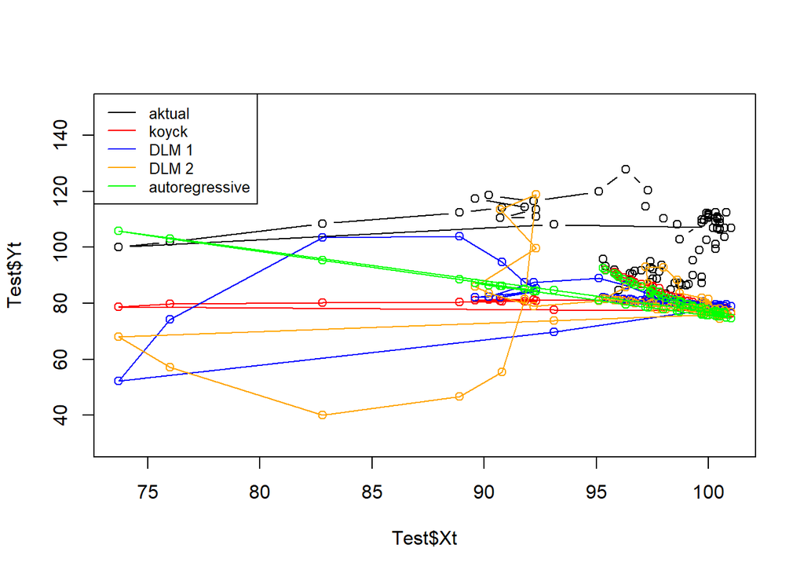

```r
par(mfrow=c(1,1))
plot(Test$Xt, Test$Yt, type="b", col="black", ylim=c(30,150))
points(Test$Xt, Fore.koyck$forecasts,col="red")
lines(Test$Xt, Fore.koyck$forecasts,col="red")
points(Test$Xt, Fore.dlm$forecasts,col="blue")
lines(Test$Xt, Fore.dlm$forecasts,col="blue")
points(Test$Xt, Fore.dlm2$forecasts,col="orange")
lines(Test$Xt, Fore.dlm2$forecasts,col="orange")
points(Test$Xt, Fore.ardl$forecasts,col="green")
lines(Test$Xt, Fore.ardl$forecasts,col="green")
legend("topleft",c("aktual", "koyck","DLM 1","DLM 2", "autoregressive"), lty=1, col=c("black","red","blue","orange","green"), cex=0.8)
```

# Berdasarkan plot tersebut, terlihat bahwa plot yang paling mendekati data aktualnya adalah Model autoregressive, sehingga dapat disimpulkan model terbaik dalam hal ini adalah model regresi autoregressive

```r
Data <- rio::import("https://raw.githubusercontent.com/Fhar1st/mpdw/main/Pertemuan%203/DATA%20-%20Minggu%203.csv")
colnames(Data) <- c("t", "Yt", "Y(t-1)", "Xt")
str(Data)
```

```
## 'data.frame':    318 obs. of  4 variables:
##  $ t     : int  1 2 3 4 5 6 7 8 9 10 ...
##  $ Yt    : num  75.7 74.8 73.3 75.8 79.5 79.3 81.1 79.9 80.2 82.4 ...
##  $ Y(t-1): num  NA 75.7 74.8 73.3 75.8 79.5 79.3 81.1 79.9 80.2 ...
##  $ Xt    : num  63.8 64.8 64.9 65.2 64.7 65.2 65.3 65.4 65.6 65.8 ...
```

```r
Data
```

```
##       t    Yt Y(t-1)    Xt
## 1     1  75.7     NA  63.8
## 2     2  74.8   75.7  64.8
## 3     3  73.3   74.8  64.9
## 4     4  75.8   73.3  65.2
## 5     5  79.5   75.8  64.7
## 6     6  79.3   79.5  65.2
## 7     7  81.1   79.3  65.3
## 8     8  79.9   81.1  65.4
## 9     9  80.2   79.9  65.6
## 10   10  82.4   80.2  65.8
## 11   11  83.0   82.4  66.1
## 12   12  84.3   83.0  66.4
## 13   13  79.1   84.3  66.2
## 14   14  84.8   79.1  66.7
```

[output cut: 304 more lines]

## Pembagian Data

```r
#SPLIT DATA
Train<-Data[1:238,]
Test<-Data[239:318,]
```

```r
#data time series
Train.ts<-ts(Train)
Test.ts<-ts(Test)
Data.ts<-ts(Data)
```

## Model Koyck

### Pemodelan

```r
#MODEL KOYCK
Model.koyck <- koyckDlm(x = Train$Xt, y = Train$Yt)
summary(Model.koyck)
```

```
##
## Call:
## "Y ~ (Intercept) + Y.1 + X.t"
##
## Residuals:
##      Min       1Q   Median       3Q      Max
## -18.2542  -2.2385  -0.2983   1.9398  25.1086
##
## Coefficients:
##             Estimate Std. Error t value Pr(>|t|)
## (Intercept)  9.02691    4.24820   2.125   0.0346 *
## Y.1          0.94438    0.02055  45.961   <2e-16 ***
## X.t         -0.04857    0.04121  -1.179   0.2398
## ---
## Signif. codes:  0 '***' 0.001 '**' 0.01 '*' 0.05 '.' 0.1 ' ' 1
##
## Residual standard error: 4.781 on 234 degrees of freedom
## Multiple R-Squared: 0.9085,  Adjusted R-squared: 0.9077
## Wald test:  1162 on 2 and 234 DF,  p-value: < 2.2e-16
##
## Diagnostic tests:
## NULL
##
##                             alpha        beta       phi
## Geometric coefficients:  162.3064 -0.04857131 0.9443835
```

```r
AIC(Model.koyck)
```

```
## [1] 1419.228
```

```r
BIC(Model.koyck)
```

```
## [1] 1433.1
```

### Peramalan dan Akurasi

Berikut adalah hasil peramalan y untuk 80 periode kedepan menggunakan model koyck

```r
Fore.koyck <- forecast(model = Model.koyck, x=Test$Xt, h=80)
Fore.koyck
```

```
## $forecasts
##  [1] 92.69792 91.93560 91.19624 90.49315 89.82430 89.18294 88.56268 87.97205
##  [9] 87.40942 86.86351 86.32367 85.81386 85.31783 84.86882 84.44478 84.04432
## [17] 83.64185 83.27148 82.90228 82.54389 82.19573 81.85721 81.53267 81.23103
## [25] 80.92674 80.64423 80.36286 80.07771 79.80842 79.57353 79.33714 79.09932
## [33] 78.85531 78.62486 78.38780 78.17364 77.98110 77.79442 77.60355 77.44758
## [41] 77.64513 78.77399 79.72835 80.29934 80.54230 80.67945 80.76041 80.81258
## [49] 80.93956 80.98176 81.15276 81.28511 81.31295 81.19839 81.03191 80.82613
## [57] 80.63664 80.41883 80.18400 79.95737 79.69477 79.44192 79.19342 78.96360
## [65] 78.74170 78.53214 78.29538 78.11065 77.91676 77.73365 77.59473 77.42954
## [73] 77.26867 77.14104 76.99622 76.85945 76.74001 76.61749 76.50665 76.37282
##
## $call
## forecast.koyckDlm(model = Model.koyck, x = Test$Xt, h = 80)
##
## attr(,"class")
## [1] "forecast.koyckDlm" "dLagM"
```

```r
Mape.koyck <- MAPE(Fore.koyck$forecasts, Test$Yt)
#akurasi data training
GoF(Model.koyck)
```

```
##               n      MAE          MPE       MAPE      sMAPE      MASE      MSE
## Model.koyck 237 3.152685 -0.002456101 0.03390863 0.03399139 0.9843018 22.57109
##                 MRAE     GMRAE
## Model.koyck 1.232581 0.9409145
```

## Regression with Distributed Lag

### Pemodelan (Lag=2)

```r
Model.dlm <- dlm(x = Train$Xt,y = Train$Yt , q = 2)
summary(Model.dlm)
```

```
##
## Call:
## lm(formula = model.formula, data = design)
##
## Residuals:
##     Min      1Q  Median      3Q     Max
## -27.852 -11.038  -3.884  11.290  39.491
##
## Coefficients:
##             Estimate Std. Error t value Pr(>|t|)
## (Intercept) 138.8639    10.2435  13.556   <2e-16 ***
## x.t           1.1430     2.4050   0.475    0.635
## x.1          -0.5649     2.8571  -0.198    0.843
## x.2          -1.1801     2.3811  -0.496    0.621
## ---
## Signif. codes:  0 '***' 0.001 '**' 0.01 '*' 0.05 '.' 0.1 ' ' 1
##
## Residual standard error: 15.09 on 232 degrees of freedom
## Multiple R-squared:  0.0926, Adjusted R-squared:  0.08087
## F-statistic: 7.892 on 3 and 232 DF,  p-value: 4.91e-05
##
## AIC and BIC values for the model:
##        AIC      BIC
## 1 1956.726 1974.045
```

```r
AIC(Model.dlm)
```

```
## [1] 1956.726
```

```r
BIC(Model.dlm)
```

```
## [1] 1974.045
```

Dari hasil diatas, didapat bahwa hanya $P-value$ dari intercept $<0.05$. Hal ini menunjukkan bahwa hanya intercept yang memilki pengaruh signifikan terhadap $y$. Adapun model keseluruhan yang terbentuk adalah sebagai berikut

$$\hat{Y_t}=138.8639+1.1430X_t-0.5649X_{t-1}-1.1801X_{t-2}$$

### Peramalan dan Akurasi

Berikut merupakan hasil peramalan $y$ untuk 80 periode kedepan

```r
Fore.dlm <- forecast(model = Model.dlm, x=Test$Xt, h=80)
Fore.dlm
```

```
## $forecasts
##  [1]  82.08370  81.84901  82.01371  81.78406  81.36983  81.42394  81.53587
##  [8]  81.24469  80.94847  81.11688  81.40093  80.76446  80.51731  79.89064
## [15]  79.76254  80.23459  80.80612  80.29508  80.27520  80.51389  80.15748
## [22]  80.03709  79.80240  79.39558  79.79127  79.56904  79.49638  79.90216
## [29]  79.32217  78.39290  78.96176  79.60727  79.54099  78.96101  78.94617
## [36]  78.49162  77.90393  78.36724  78.88969  78.03069  69.84346  52.26893
## [43]  74.23517 103.60321 104.02044  94.72169  87.59272  85.35713  82.06570
## [50]  84.20829  82.10649  82.42924  87.56276  89.03980  86.41310  83.45593
## [57]  81.36061  81.15141  81.50336  80.33464  80.71313  80.14456  79.13655
## [64]  78.79126  78.72603  78.78755  79.58398  78.21765  78.18265  78.90081
## [71]  77.62863  78.82416  79.36916  77.91506  78.65100  78.95863  78.13996
## [78]  78.48154  78.49029  78.99658
##
## $call
## forecast.dlm(model = Model.dlm, x = Test$Xt, h = 80)
##
## attr(,"class")
## [1] "forecast.dlm" "dLagM"
```

```r
Mape.dlm <- MAPE(Fore.dlm$forecasts, Test$Yt)
#akurasi data training
GoF(Model.dlm)
```

```
##             n      MAE         MPE      MAPE     sMAPE     MASE      MSE
## Model.dlm 236 12.44777 -0.02571939 0.1373096 0.1355141 3.877553 223.8463
##               MRAE    GMRAE
## Model.dlm 11.88632 4.512206
```

### *Lag* Optimum

```r
#penentuan lag optimum
finiteDLMauto(formula = Yt ~ Xt,
              data = data.frame(Train), q.min = 1, q.max = 6,
              model.type = "dlm", error.type = "AIC", trace = FALSE)
```

```
##   q - k    MASE     AIC      BIC   GMRAE   MBRAE R.Adj.Sq Ljung-Box
## 6     6 3.78845 1922.58 1953.601 4.30485 1.21527  0.10357         0
```

Berdasarkan output tersebut, lag optimum didapatkan ketika lag=6. Selanjutnya dilakukan pemodelan untuk lag=6

```r
#model dlm dengan lag optimum
Model.dlm2 <- dlm(x = Train$Xt,y = Train$Yt , q = 6)
summary(Model.dlm2)
```

```
##
## Call:
## lm(formula = model.formula, data = design)
##
## Residuals:
##     Min      1Q  Median      3Q     Max
## -24.626 -11.979  -3.195  11.677  38.075
##
## Coefficients:
##             Estimate Std. Error t value Pr(>|t|)
## (Intercept) 146.9035    10.5729  13.894   <2e-16 ***
## x.t           0.2140     2.4939   0.086    0.932
## x.1           0.2360     2.9790   0.079    0.937
## x.2           1.0210     3.0939   0.330    0.742
## x.3          -0.1463     3.1156  -0.047    0.963
## x.4           0.1518     3.0855   0.049    0.961
## x.5          -0.3505     2.9495  -0.119    0.906
## x.6          -1.8339     2.4525  -0.748    0.455
## ---
## Signif. codes:  0 '***' 0.001 '**' 0.01 '*' 0.05 '.' 0.1 ' ' 1
##
## Residual standard error: 14.93 on 224 degrees of freedom
## Multiple R-squared:  0.1307, Adjusted R-squared:  0.1036
## F-statistic: 4.813 on 7 and 224 DF,  p-value: 4.558e-05
##
## AIC and BIC values for the model:
##       AIC      BIC
## 1 1922.58 1953.601
```

```r
AIC(Model.dlm2)
```

```
## [1] 1922.58
```

```r
BIC(Model.dlm2)
```

```
## [1] 1953.601
```

Dari hasil tersebut tidak terdapat peubah yang berpengaruh signifikan terhadap taraf nyata 5%. Adapun keseluruhan model yang terbentuk adalah

$$\hat{Y_t}=146.9035+0.2140X_t+...-1.8339_{t-6}$$

Adapun hasil peramalan 80 periode ke depan menggunakan model tersebut adalah sebagai berikut

```r
#peramalan dan akurasi
Fore.dlm2 <- forecast(model = Model.dlm2, x=Test$Xt, h=80)
Mape.dlm2<- MAPE(Fore.dlm2$forecasts, Test$Yt)
#akurasi data training
GoF(Model.dlm2)
```

```
##              n      MAE         MPE      MAPE     sMAPE     MASE      MSE
## Model.dlm2 232 12.23783 -0.02467698 0.1346804 0.1328447 3.788445 215.1898
##                MRAE    GMRAE
## Model.dlm2 11.45986 4.304852
```

Model tersebut merupakan model yang cukup baik dengan nilai MAPE yang kurang dari 15%.

## Model Autoregressive

### Pemodelan

```r
Model.ardl <- ardlDlm(x = Train$Xt, y = Train$Yt, p = 1 , q = 1)
summary(Model.ardl)
```

```
##
## Time series regression with "ts" data:
## Start = 2, End = 238
##
## Call:
## dynlm(formula = as.formula(model.text), data = data, start = 1)
##
## Residuals:
##      Min       1Q   Median       3Q      Max
## -18.0236  -2.2282  -0.3501   1.9571  24.1239
##
## Coefficients:
##             Estimate Std. Error t value Pr(>|t|)
## (Intercept)  9.32996    4.23266   2.204   0.0285 *
## X.t         -1.09707    0.72334  -1.517   0.1307
## X.1          1.04505    0.72212   1.447   0.1492
## Y.1          0.94564    0.02053  46.058   <2e-16 ***
## ---
## Signif. codes:  0 '***' 0.001 '**' 0.01 '*' 0.05 '.' 0.1 ' ' 1
##
## Residual standard error: 4.77 on 233 degrees of freedom
## Multiple R-squared:  0.9093, Adjusted R-squared:  0.9082
## F-statistic: 778.9 on 3 and 233 DF,  p-value: < 2.2e-16
```

```r
AIC(Model.ardl)
```

```
## [1] 1419.1
```

```r
BIC(Model.ardl)
```

```
## [1] 1436.44
```

Hasil di atas menunjukkan bahwa selain peubah $y_{t-1}$, hasil uji t menunjukkan nilai-p pada peubah $\ge0.05$ Hal ini menunjukkan bahwa peubah $y_{t-1}$ berpengaruh signifikan terhadap $y_t$, sementara $x_t$ dan $x_{t-1}$ tidak berpengaruh signifikan terhadap $y_t$. Model keseluruhannya adalah sebagai berikut:

$$\hat{Y}=9.32996-1.09707X_t+1.04505X_{t-1}+0.94564Y_{t-1}$$

### Peramalan dan Akurasi

```r
Fore.ardl <- forecast(model = Model.ardl, x=Test$Xt, h=80)
Fore.ardl
```

```
## $forecasts
##  [1]  92.58019  91.80969  90.74674  90.04989  89.38571  88.64273  87.82003
##  [8]  87.24585  86.69769  85.95470  85.01709  84.65296  83.97951  84.09501
## [15]  83.78621  83.49420  82.66952  82.63161  81.94793  81.50001  81.06604
## [22]  80.64525  80.34664  80.27847  79.67068  79.62365  79.14555  78.56813
## [29]  78.44011  78.75788  78.31124  77.87326  77.33378  77.24165  76.71570
## [36]  76.85577  76.99863  76.81500  76.41675  76.90219  84.62795 105.79714
## [43] 103.01836  95.33414  88.48181  86.29233  85.11038  84.48920  86.17962
## [50]  84.35076  87.25549  86.52245  84.26214  81.03327  79.69408  78.58467
## [57]  78.69032  77.80807  77.15157  77.04808  75.95764  75.86182  75.65630
## [64]  75.78067  75.68407  75.69722  74.83200  75.72751  75.29947  75.31272
## [71]  76.09320  75.33177  75.23356  75.79372  75.25238  75.26298  75.49243
## [78]  75.28097  75.39973  74.74929
##
## $call
## forecast.ardlDlm(model = Model.ardl, x = Test$Xt, h = 80)
##
## attr(,"class")
## [1] "forecast.ardlDlm" "dLagM"
```

Data di atas merupakan hasil peramalan untuk 80 periode ke depan menggunakan Model Autoregressive dengan $p=1$ dan $q=1$.

```r
Mape.ardl <- MAPE(Fore.ardl$forecasts, Test$Yt)
Mape.ardl
```

```
## [1] 0.1962044
```

```r
#akurasi data training
GoF(Model.ardl)
```

```
##              n      MAE          MPE       MAPE      sMAPE      MASE      MSE
## Model.ardl 237 3.161371 -0.002434306 0.03400318 0.03406463 0.9870137 22.36937
##                MRAE     GMRAE
## Model.ardl 1.230324 0.9493943
```

### *Lag* Optimum

```r
#penentuan lag optimum
Model.ardl.opt <- ardlBoundOrders(data = data.frame(Data), ic = "AIC",
                                  formula = Yt ~ Xt )
min_p=c()
for(i in 1:6){
  min_p[i]=min(Model.ardl.opt$Stat.table[[i]])
}
Q_opt=which(min_p==min(min_p, na.rm = TRUE))
P_opt=which(Model.ardl.opt$Stat.table[[Q_opt]] ==
              min(Model.ardl.opt$Stat.table[[Q_opt]], na.rm = TRUE))
data.frame("q_optimum" = P_opt, "p_optimum" = P_opt,
           "AIC"=Model.ardl.opt$min.Stat)
```

```
##   q_optimum p_optimum      AIC
## 1        15        15 1729.435
```

Selanjutnya dapat dilakukan pemodelan dengan nilai $p$ dan $q$ optimum seperti inisialisasi di langkah sebelumnya.

## Pemodelan DLM & ARDL dengan Library `dynlm`

```r
#sama dengan model dlm q=1
Cons_lm1 <- dynlm(Yt ~ Xt+L(Xt),data = Train.ts)
#sama dengan model ardl p=1 q=0
Cons_lm2 <- dynlm(Yt ~ Xt+L(Yt),data = Train.ts)
#sama dengan ardl p=1 q=1
Cons_lm3 <- dynlm(Yt ~ Xt+L(Xt)+L(Yt),data = Train.ts)
#sama dengan dlm p=2
Cons_lm4 <- dynlm(Yt ~ Xt+L(Xt)+L(Xt,2),data = Train.ts)
```

### Ringkasan Model

```r
summary(Cons_lm1)
```

```
##
## Time series regression with "ts" data:
## Start = 2, End = 238
##
## Call:
## dynlm(formula = Yt ~ Xt + L(Xt), data = Train.ts)
##
## Residuals:
##     Min      1Q  Median      3Q     Max
## -26.329 -11.240  -4.144  11.171  39.953
##
## Coefficients:
##             Estimate Std. Error t value Pr(>|t|)
## (Intercept) 136.9089    10.1516  13.486   <2e-16 ***
## Xt            0.3094     2.2924   0.135    0.893
## L(Xt)        -0.8852     2.2867  -0.387    0.699
## ---
## Signif. codes:  0 '***' 0.001 '**' 0.01 '*' 0.05 '.' 0.1 ' ' 1
##
## Residual standard error: 15.13 on 234 degrees of freedom
## Multiple R-squared:  0.0838, Adjusted R-squared:  0.07596
## F-statistic:  10.7 on 2 and 234 DF,  p-value: 3.574e-05
```

```r
summary(Cons_lm2)
```

```
##
## Time series regression with "ts" data:
## Start = 2, End = 238
##
## Call:
## dynlm(formula = Yt ~ Xt + L(Yt), data = Train.ts)
##
## Residuals:
##      Min       1Q   Median       3Q      Max
## -18.2628  -2.2397  -0.3136   1.9705  25.0869
##
## Coefficients:
##             Estimate Std. Error t value Pr(>|t|)
## (Intercept)  9.34170    4.24254   2.202   0.0286 *
## Xt          -0.05195    0.04115  -1.263   0.2080
## L(Yt)        0.94392    0.02054  45.944   <2e-16 ***
## ---
## Signif. codes:  0 '***' 0.001 '**' 0.01 '*' 0.05 '.' 0.1 ' ' 1
##
## Residual standard error: 4.781 on 234 degrees of freedom
## Multiple R-squared:  0.9085, Adjusted R-squared:  0.9077
## F-statistic:  1162 on 2 and 234 DF,  p-value: < 2.2e-16
```

```r
summary(Cons_lm3)
```

```
##
## Time series regression with "ts" data:
## Start = 2, End = 238
##
## Call:
## dynlm(formula = Yt ~ Xt + L(Xt) + L(Yt), data = Train.ts)
##
## Residuals:
##      Min       1Q   Median       3Q      Max
## -18.0236  -2.2282  -0.3501   1.9571  24.1239
##
## Coefficients:
##             Estimate Std. Error t value Pr(>|t|)
## (Intercept)  9.32996    4.23266   2.204   0.0285 *
## Xt          -1.09707    0.72334  -1.517   0.1307
## L(Xt)        1.04505    0.72212   1.447   0.1492
## L(Yt)        0.94564    0.02053  46.058   <2e-16 ***
## ---
## Signif. codes:  0 '***' 0.001 '**' 0.01 '*' 0.05 '.' 0.1 ' ' 1
##
## Residual standard error: 4.77 on 233 degrees of freedom
## Multiple R-squared:  0.9093, Adjusted R-squared:  0.9082
## F-statistic: 778.9 on 3 and 233 DF,  p-value: < 2.2e-16
```

```r
summary(Cons_lm4)
```

```
##
## Time series regression with "ts" data:
## Start = 3, End = 238
##
## Call:
## dynlm(formula = Yt ~ Xt + L(Xt) + L(Xt, 2), data = Train.ts)
##
## Residuals:
##     Min      1Q  Median      3Q     Max
## -27.852 -11.038  -3.884  11.290  39.491
##
## Coefficients:
##             Estimate Std. Error t value Pr(>|t|)
## (Intercept) 138.8639    10.2435  13.556   <2e-16 ***
## Xt            1.1430     2.4050   0.475    0.635
## L(Xt)        -0.5649     2.8571  -0.198    0.843
## L(Xt, 2)     -1.1801     2.3811  -0.496    0.621
## ---
## Signif. codes:  0 '***' 0.001 '**' 0.01 '*' 0.05 '.' 0.1 ' ' 1
##
## Residual standard error: 15.09 on 232 degrees of freedom
## Multiple R-squared:  0.0926, Adjusted R-squared:  0.08087
## F-statistic: 7.892 on 3 and 232 DF,  p-value: 4.91e-05
```

### SSE

```r
deviance(Cons_lm1)
```

```
## [1] 53569.38
```

```r
deviance(Cons_lm2)
```

```
## [1] 5349.195
```

```r
deviance(Cons_lm3)
```

```
## [1] 5301.541
```

```r
deviance(Cons_lm4)
```

```
## [1] 52827.74
```

### Uji Diagnostik

```r
#uji model
if(require("lmtest")) encomptest(Cons_lm1, Cons_lm2)
```

```
## Encompassing test
##
## Model 1: Yt ~ Xt + L(Xt)
## Model 2: Yt ~ Xt + L(Yt)
## Model E: Yt ~ Xt + L(Xt) + L(Yt)
##           Res.Df Df         F Pr(>F)
## M1 vs. ME    233 -1 2121.3467 <2e-16 ***
## M2 vs. ME    233 -1    2.0944 0.1492
## ---
## Signif. codes:  0 '***' 0.001 '**' 0.01 '*' 0.05 '.' 0.1 ' ' 1
```

#### Autokorelasi

```r
#durbin watson
dwtest(Cons_lm1)
```

```
##
##  Durbin-Watson test
##
## data:  Cons_lm1
## DW = 0.10466, p-value < 2.2e-16
## alternative hypothesis: true autocorrelation is greater than 0
```

```r
dwtest(Cons_lm2)
```

```
##
##  Durbin-Watson test
##
## data:  Cons_lm2
## DW = 2.0526, p-value = 0.6095
## alternative hypothesis: true autocorrelation is greater than 0
```

```r
dwtest(Cons_lm3)
```

```
##
##  Durbin-Watson test
##
## data:  Cons_lm3
## DW = 2.0526, p-value = 0.6164
## alternative hypothesis: true autocorrelation is greater than 0
```

```r
dwtest(Cons_lm4)
```

```
##
##  Durbin-Watson test
##
## data:  Cons_lm4
## DW = 0.11007, p-value < 2.2e-16
## alternative hypothesis: true autocorrelation is greater than 0
```

#### Heterogenitas

```r
bptest(Cons_lm1)
```

```
##
##  studentized Breusch-Pagan test
##
## data:  Cons_lm1
## BP = 14.74, df = 2, p-value = 0.0006298
```

```r
bptest(Cons_lm2)
```

```
##
##  studentized Breusch-Pagan test
##
## data:  Cons_lm2
## BP = 9.872, df = 2, p-value = 0.007183
```

```r
bptest(Cons_lm3)
```

```
##
##  studentized Breusch-Pagan test
##
## data:  Cons_lm3
## BP = 12.775, df = 3, p-value = 0.005149
```

```r
bptest(Cons_lm4)
```

```
##
##  studentized Breusch-Pagan test
##
## data:  Cons_lm4
## BP = 16.002, df = 3, p-value = 0.001133
```

#### Kenormalan

```r
shapiro.test(residuals(Cons_lm1))
```

```
##
##  Shapiro-Wilk normality test
##
## data:  residuals(Cons_lm1)
## W = 0.95372, p-value = 6.901e-07
```

```r
shapiro.test(residuals(Cons_lm2))
```

```
##
##  Shapiro-Wilk normality test
##
## data:  residuals(Cons_lm2)
## W = 0.87817, p-value = 7.533e-13
```

```r
shapiro.test(residuals(Cons_lm3))
```

```
##
##  Shapiro-Wilk normality test
##
## data:  residuals(Cons_lm3)
## W = 0.88925, p-value = 3.625e-12
```

```r
shapiro.test(residuals(Cons_lm4))
```

```
##
##  Shapiro-Wilk normality test
##
## data:  residuals(Cons_lm4)
## W = 0.95459, p-value = 9.029e-07
```

## Perbandingan Model

```r
Akurasi <- matrix(c(Mape.koyck, Mape.dlm, Mape.dlm2, Mape.ardl))
row.names(Akurasi)<- c("Koyck","DLM 1","DLM 2","Autoregressive")
colnames(Akurasi) <- c("MAPE")
Akurasi
```

```
##                     MAPE
## Koyck          0.1965626
## DLM 1          0.2035285
## DLM 2          0.2220657
## Autoregressive 0.1962044
```

Berdasarkan nilai MAPE, model paling optimum didapat pada Model Autoregressive karena memiliki nilai MAPE yang terkecil.

### Plot

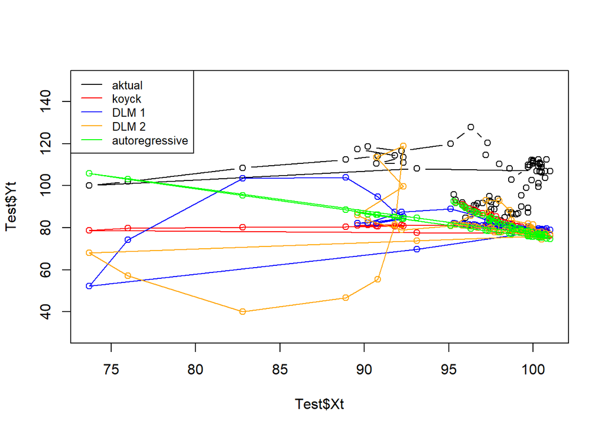

```r
par(mfrow=c(1,1))
plot(Test$Xt, Test$Yt, type="b", col="black", ylim=c(30,150))
points(Test$Xt, Fore.koyck$forecasts,col="red")
lines(Test$Xt, Fore.koyck$forecasts,col="red")
points(Test$Xt, Fore.dlm$forecasts,col="blue")
lines(Test$Xt, Fore.dlm$forecasts,col="blue")
points(Test$Xt, Fore.dlm2$forecasts,col="orange")
lines(Test$Xt, Fore.dlm2$forecasts,col="orange")
points(Test$Xt, Fore.ardl$forecasts,col="green")
lines(Test$Xt, Fore.ardl$forecasts,col="green")
legend("topleft",c("aktual", "koyck","DLM 1","DLM 2", "autoregressive"), lty=1, col=c("black","red","blue","orange","green"), cex=0.8)
```

Berdasarkan plot tersebut, terlihat bahwa plot yang paling mendekati data aktualnya adalah Model autoregressive, sehingga dapat disimpulkan model terbaik dalam hal ini adalah model regresi autoregressive